# **2. Feature engineering**

### Question 1

### A histogram of shot counts (goals and no-goals separated), binned by distance

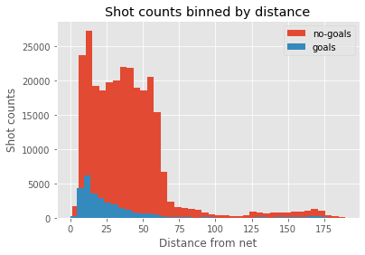

From this histogram, it is easy to conclude that most of the shots are concentrated in the range of 5 to 65. The majority of these goals are concentrated in the range of 5 to 30. Therefore, we can conclude that shots and goals in the game are mainly from short distances.

### A histogram of shot counts (goals and no-goals separated), binned by angle

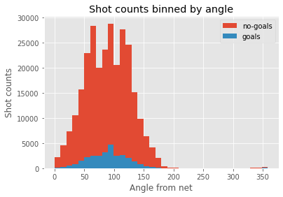

This histogram indicates that the majority of shot angles are concentrated in the range of 40 degrees to 150 degrees. The vast majority of these goal angles are also concentrated in this range. In particular, the greatest number of goals were scored in a direction almost perpendicular to the goal net (around 90 degrees). In addition, a very small number of shots and goals were shot from the back of the net.

### A 2D histogram where one axis is the distance and the other is the angle. Do not need to separate goals and no-goals

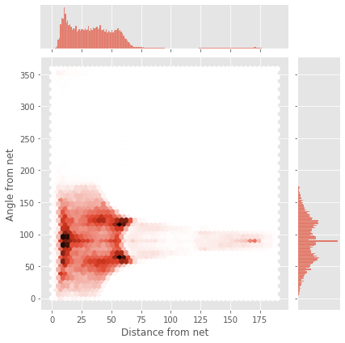

The 2D histogram shows that the vast majority of shots were taken from a distance of 5ft to 60ft from the goal, and from an angle of 40 to 150 degrees.